# Phylogenetics and Comparative Methods

Michelle Jonika

2022-10-16

## Phylogenetics

Due to time constraints this lesson will focus primarily on using phylogenies to do comparative methods. If you are interested in learning to build phylogenies there are a number of great workshops, classes, and online tutorials:

- BEAST (Bayesian Evolutionary Analysis Sampling Trees): https://beast.community
- Bayesian Divergence-Time Estimation using BEAST: http://treethinkers.org/tutorials/divergence-time-estimation-using-beast/
- Taming the BEAST: https://taming-the-beast.org/tutorials/
- RevBayes: https://revbayes.github.io/tutorials/
- Estimating a Time-Calibrated Phylogeny of Fossil and Extant Taxa Using Morphological Data: https://revbayes.github.io/tutorials/fbd_simple/
- RAxML: https://raxml-ng.vital-it.ch/#/

Additionally, here are some highly recommended books that are helpful when working with phylogenies and phylogenetic comparative methods:

- Analysis of Phylogenetics and Evolution in R (Paradis)
- Phylogenetic Comparative Methods in R (Revell and Harmon)
- Tree Thinking (Baum and Smith)
- The Phylogenetic Handbook
- Phylogenetic Comparative Methods: Learning from trees (Harmon)
- Inferring Phylogenies (Felsenstein)

## Packages

- APE (Analysis of Phylogenetics and Evolution in R)
- Phytools
- Geiger
- There are many more packages that you may find useful or want to use in your research, but there is no possible way to cover them all in this workshop. Here is a helpful list of phylogenetic and phylogenetic comparative method packages: https://cran.microsoft.com/snapshot/2019-02-07/web/views/Phylogenetics.html

## Trees in R

The first thing we will go over is how we get trees in and out of R and the way that they are stored while being used in R. Most of this is based on the R package APE which was one of the first R packages focused on dealing with phylogenies.

### The phylo object in R

Phylogenetic trees in R are stored in a class called `phylo`. Lets simulate a small tree and explore this class of object.

```r
library(ape)
```

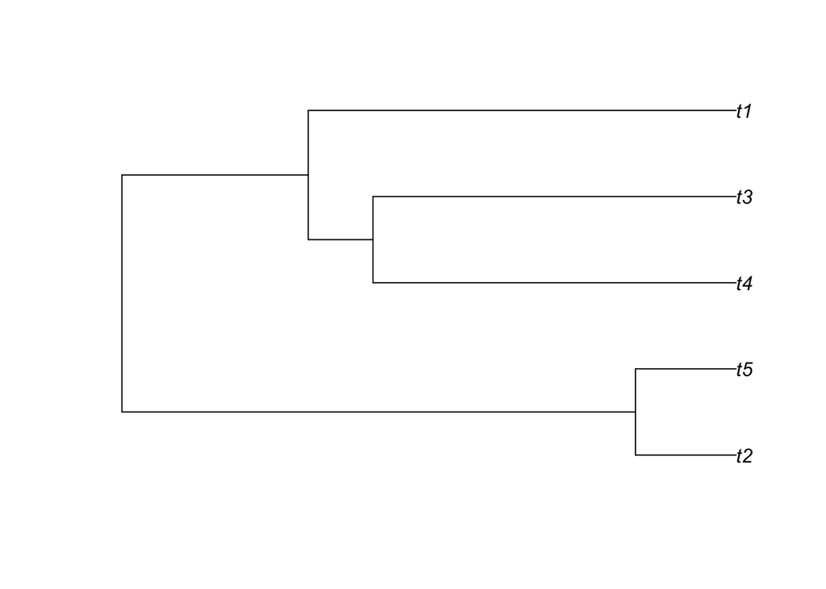

```r
# first lets just simulate a simple tree
set.seed(1)
tree <- rcoal(5)
plot(tree)
```

This phylogeny is stored as a list in R. The elements of this list include

- edge: this is a matrix where each row is a branch of the phylogeny. In the first column will be the node number of the node towards the root of the tree and in the right column will be the node number towards the tips of the tree.
- edge.length: this is a vector where each element is the length of the branches described in the edge matrix
- tip.label vector: this is a character vector where each element is the name for a tip in the phylogeny
- Nnode: this vector will be a length of one and is the number of internal nodes in the tree.

Lets look at the edge matrix, edge.length vector and the tree at the same time to see the concordance between these.

```r
tree$edge
```

```
##      [,1] [,2]
## [1,]    6    9
## [2,]    9    1
## [3,]    9    2
## [4,]    6    7
## [5,]    7    8
## [6,]    8    3
## [7,]    8    4
## [8,]    7    5
```

```r
tree$edge.length
```

```
## [1] 0.38530463 0.07551818 0.07551818 0.13979526 0.04856891 0.27245865 0.27245865
## [8] 0.32102756
```

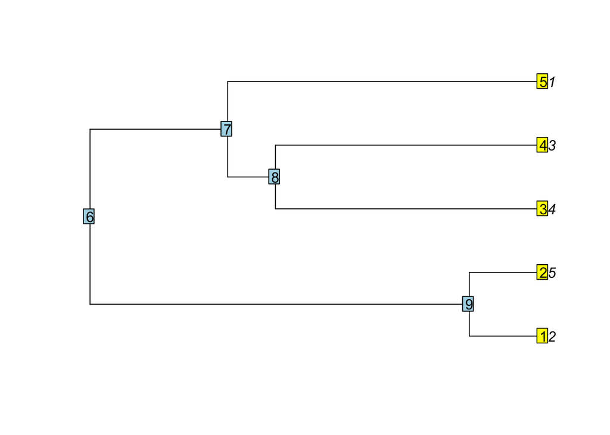

```r
plot(tree)
nodelabels()
tiplabels()
```

Ok, now that we understand a little bit about how a tree is stored in R lets work on reading and writing trees. One thing that you need to be aware of is that you will likely encounter two types of tree file formats. The simplest is what is called a Newick format. A slightly more complex file format is nexus these are especially common when you either have a large collection of trees or a great deal of extra information (summary statistics for nodes in the tree). These can both be read into R but we need to use different functions. For newick formatted trees we will use the function `read.tree` and for nexus formatted trees we will use the function `read.nexus`. If we want to write trees we will use the functions `write.tree` and `write.nexus`.

```r
write.tree(tree, "jonika.tree")
tree2 <- read.tree("jonika.tree")
```

### Data munging with phylogenies

Rarely will you be able to just immediately do what you want with a new phylogeny. Lets look at some of the most common tasks that you have to do before using a phylogeny. To do this lets use a dataset that is built into the R package Geiger.

```r
library(geiger)
data("geospiza")
# This returned a list to us we will take the tree which is the first element and the data that matches it which is the second element
tree <- geospiza[[1]]
dat <- geospiza[[2]]
```

One of the most common problems that we face in comparative methods is a mismatch between our tree and our data. Fortunately there are some easy function that you can use to deal with this.

```r
newlist <- treedata(tree, dat)
length(tree$tip.label)
```

```
## [1] 14
```

```r
length(newlist$phy$tip.label)
```

```
## [1] 13
```

```r
nrow(dat)
```

```
## [1] 13
```

```r
nrow(newlist$data)
```

```
## [1] 13
```

Sometimes you may need to go in and remove a tip from you phylogeny manually.

```r
small.tree <- drop.tip(tree, "olivacea")
```

Although the current tree we are using is ultrametric (the distance from the root to the tip is identical for all species) often times you will get trees where this is not the case. Sometimes this is because the tree is not time calibrated other times it is because it includes fossils. But often times even when the tree looks ultrametric you will get an error from R saying it is not. This can be do to very small rounding differences on branches leading to minuscule differences among tips. We can fix this using a function from Phytools

```r
library(phytools)
new.tree <- force.ultrametric(tree)
```

```
## *                          Note:                              *
## *    force.ultrametric does not include a formal method to    *
## *    ultrametricize a tree & should only be used to coerce    *
## *   a phylogeny that fails is.ultramtric due to rounding --   *
## *    not as a substitute for formal rate-smoothing methods.   *
```

This function should only be used for trees that are ultrametric but simply not with enough precision. If you have a tree where the branch lengths are say in units of substitutions you might look at the `chronos` function in APE as one way to convert to an ultrametric tree.

Some functions that you may want to use in R will require that your tree and data be in the same order. Lets look at how we can write a simple loop to do this.

```r
# lets use the Geospiza data that we already ran through treedata
tree <- newlist$phy
dat <- newlist$data
neworder <- c()
for(i in 1:length(tree$tip.label)){
  neworder[i] <- which(tree$tip.label[i] == rownames(dat))
}
dat2 <- dat[neworder,]

#here we can  see the old data is not in the same order when you compare
#between the data and tree
rownames(dat)
```

```
##  [1] "magnirostris" "conirostris"  "difficilis"   "scandens"     "fortis"
##  [6] "fuliginosa"   "pallida"      "fusca"        "parvulus"     "pauper"
## [11] "Pinaroloxias" "Platyspiza"   "psittacula"
```

```r
tree$tip.label
```

```
##  [1] "fuliginosa"   "fortis"       "magnirostris" "conirostris"  "scandens"
##  [6] "difficilis"   "pallida"      "parvulus"     "psittacula"   "pauper"
## [11] "Platyspiza"   "fusca"        "Pinaroloxias"
```

```r
#here we can  see the new data is in the same order when you compare
#between the data and tree
rownames(dat2)
```

```
##  [1] "fuliginosa"   "fortis"       "magnirostris" "conirostris"  "scandens"
##  [6] "difficilis"   "pallida"      "parvulus"     "psittacula"   "pauper"
## [11] "Platyspiza"   "fusca"        "Pinaroloxias"
```

```r
tree$tip.label
```

```
##  [1] "fuliginosa"   "fortis"       "magnirostris" "conirostris"  "scandens"
##  [6] "difficilis"   "pallida"      "parvulus"     "psittacula"   "pauper"
## [11] "Platyspiza"   "fusca"        "Pinaroloxias"
```

### Basic Tree Plotting

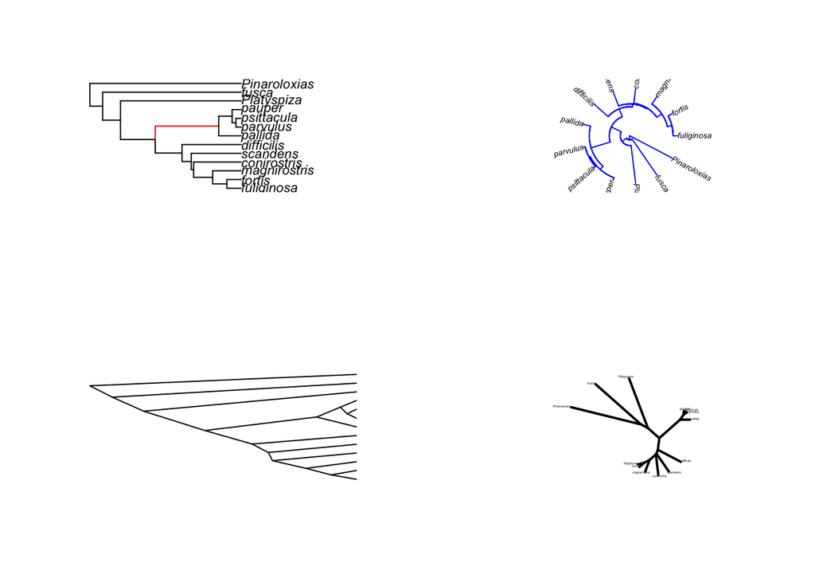

```r
par(mfcol=c(2,2))
plot(tree, type="p", edge.color = c(rep("black",14), "red",rep("black",9)))
plot(tree, type="c", show.tip.label = F)
plot(tree, type="f", cex=0.5, edge.color = "blue")
plot(tree, type="u", edge.width=2, cex=.2)
```

There are many additional arguments that you can use to fine tune the way your tree plots in R. However, I’ll be honest with you, there may be things that you want to do that are difficult/impossible in R. Often time the figures that you will see in manuscripts and talks will be a combination of a phylogeny and some aspects plotted in R and then additions that are done in PowerPoint, Adobe, or other illustration software.

### Cooler Plots

Lets look at how we can combine plots of data and trees or even inferences from our data and trees.

# Bar Plot

Let’s plot the wing length across the phylogeny

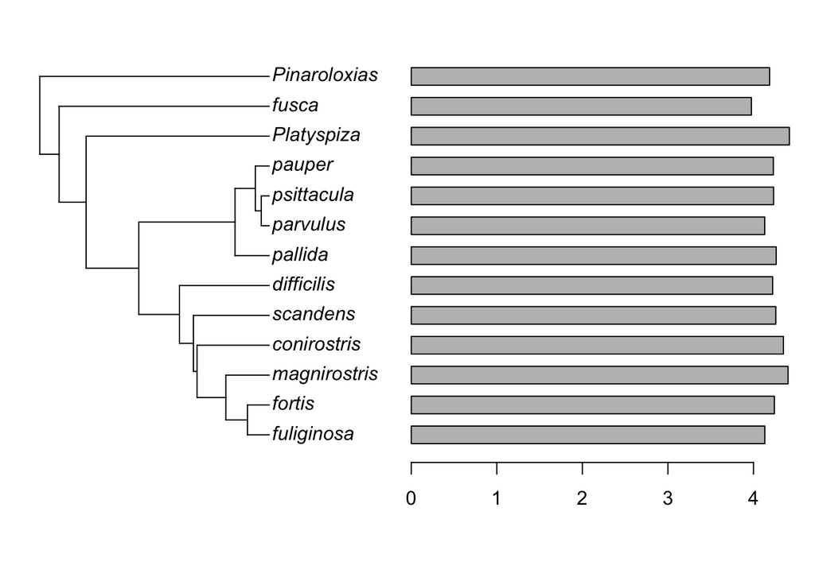

```r
plotTree.barplot(tree, dat2[,1])
```

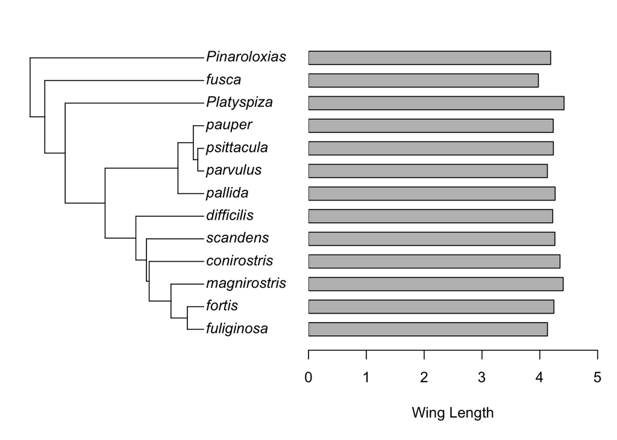

```r
#You'll notice that this plot doesn't quite extend as far as we would like on the x-axis, but we can fix that with just a little bit more code
plotTree.barplot(tree, dat2[,1],
                 args.barplot = list(xlim = c(0, 5),
                                     xlab = "Wing Length"))
```

#As mentioned above many times phylogeneticists will manually fix things about figures they don’t like in powerpoint or other editing software. For example, in the above figure, if I was doing any paired plot with the phylogeny that was more complex than a barplot (or some of the other functions available, I made need to make the phylogeny and the plot separately and then bring them together in PPT manually.

# Stochastic Map

To plot a stochastic map we will first need a discrete trait and our traits are all continuous.

```r
#this loop will take the mean of wing length in our data frame and assign a binary state to the wing length value in each row
#dependent on whether the value is above or below the median wing length value

#this allows us to discretize our contiuous trait
for(i in length(dat2)){
  x <- median(dat2[,1])
  dat2[,1] <- as.numeric(dat2[,1] >= x)
}

#let's take a look at what our wing length data looks like after discretizing
dat2
```

```
##              wingL  tarsusL  culmenL    beakD   gonysW
## fuliginosa       0 2.806514 2.094971 1.941157 1.845379
## fortis           1 2.894717 2.407025 2.362658 2.221867
## magnirostris     1 3.038950 2.724667 2.823767 2.675983
## conirostris      1 2.984200 2.654400 2.513800 2.360167
## scandens         1 2.929033 2.621789 2.144700 2.036944
## difficilis       0 2.898917 2.277183 2.011100 1.929983
## pallida          1 3.089450 2.430250 2.016350 1.949125
## parvulus         0 2.973060 1.974420 1.873540 1.813340
## psittacula       1 3.049120 2.259640 2.230040 2.073940
## pauper           0 3.035900 2.187000 2.073400 1.962100
## Platyspiza       1 3.270543 2.331471 2.347471 2.282443
## fusca            0 2.936536 2.051843 1.191264 1.401186
## Pinaroloxias     0 2.980200 2.311100 1.547500 1.630100
```

```r
#0 = small wing length; 1 = large wing length


#Now we will be using the function `make.simmap` to simulate a stochastic character map on a phylogeneitc tree

#make.simmap requires that our tip states or discrete trait that we are wishing to simulate is in a vector, so let's get that in the proper format
wing.length <- dat2[,1]
stoch.map <- make.simmap(tree, wing.length, model = "ER", nsim = 10)
```

```
## make.simmap is sampling character histories conditioned on
## the transition matrix
##
## Q =
##         0       1
## 0 -58.333  58.333
## 1  58.333 -58.333
## (estimated using likelihood);
## and (mean) root node prior probabilities
## pi =
##   0   1
## 0.5 0.5
```

```
## Done.
```

```
## no colors provided. using the following legend:
##         0         1
##   "black" "#DF536B"
```

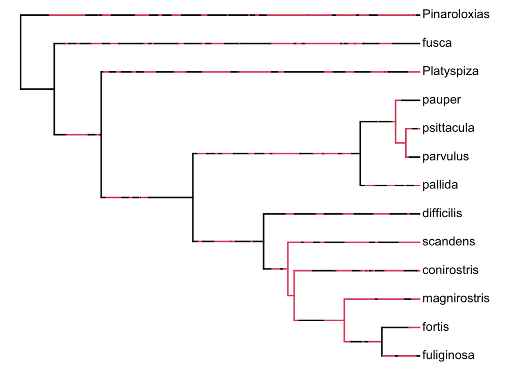

```
## no colors provided. using the following legend:
##         0         1
##   "black" "#DF536B"
```

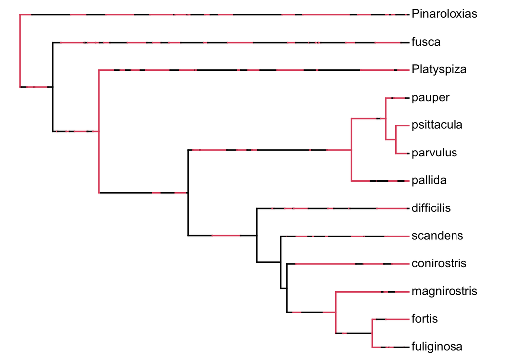

```
## no colors provided. using the following legend:
##         0         1
##   "black" "#DF536B"
```

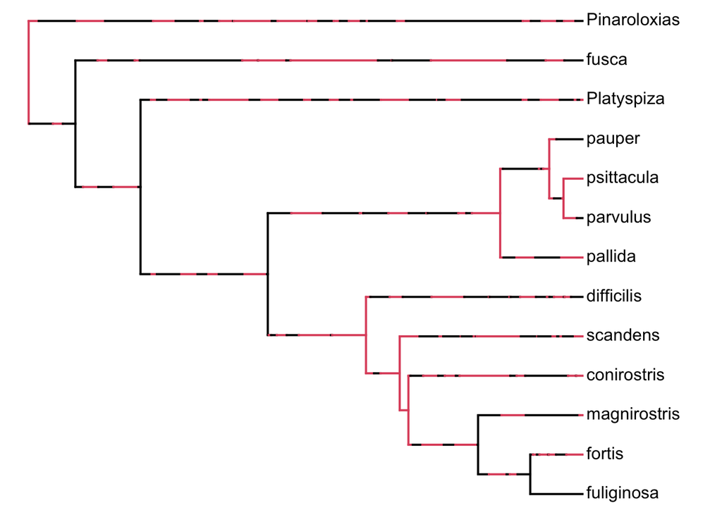

```
## no colors provided. using the following legend:
##         0         1
##   "black" "#DF536B"
```

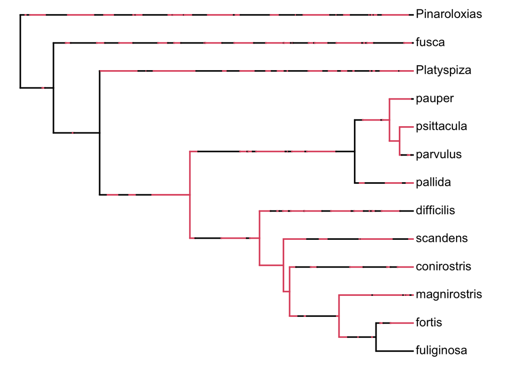

```
## no colors provided. using the following legend:
##         0         1
##   "black" "#DF536B"
```

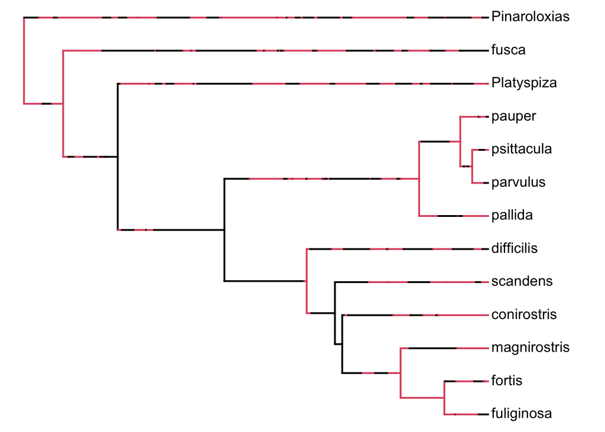

```
## no colors provided. using the following legend:
##         0         1
##   "black" "#DF536B"
```

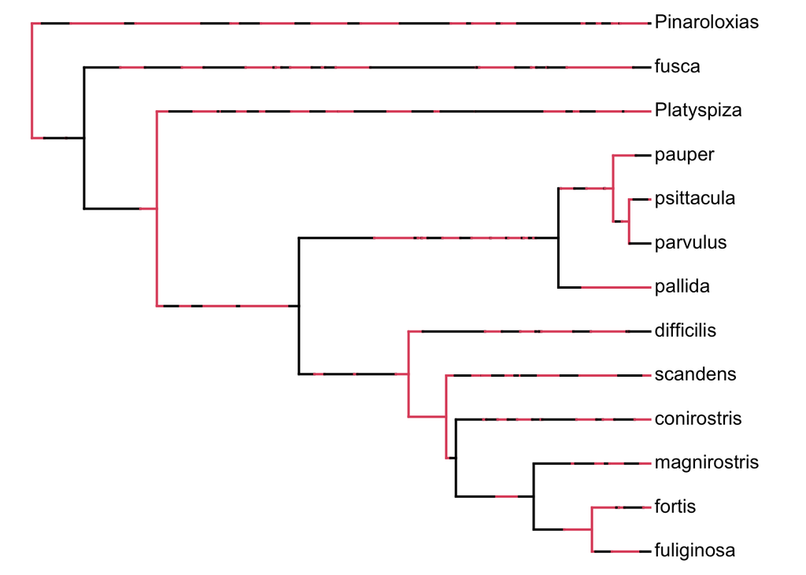

```
## no colors provided. using the following legend:
##         0         1
##   "black" "#DF536B"
```

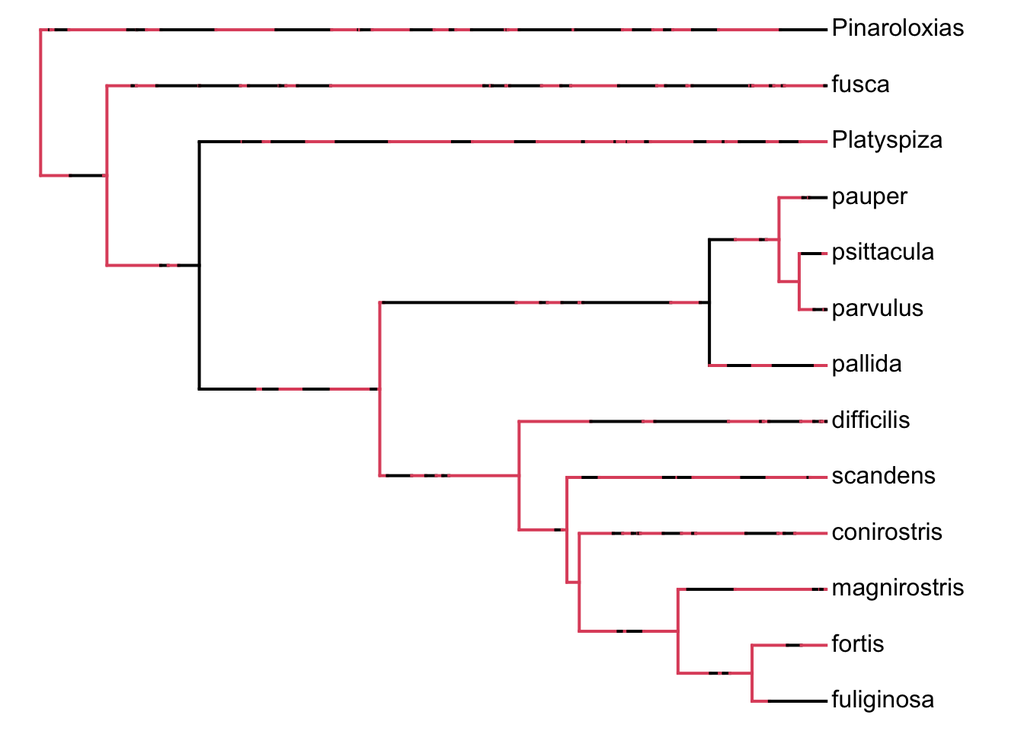

```
## no colors provided. using the following legend:
##         0         1
##   "black" "#DF536B"
```

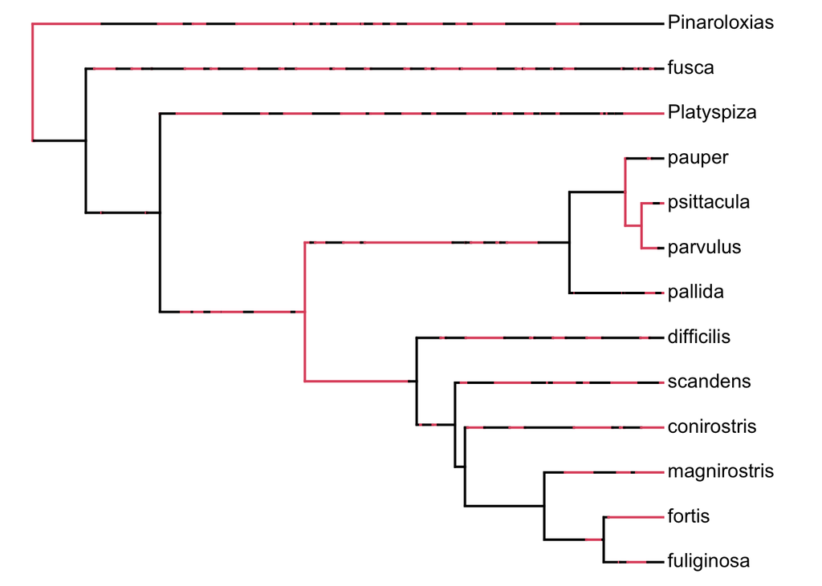

```
## no colors provided. using the following legend:
##         0         1
##   "black" "#DF536B"
```

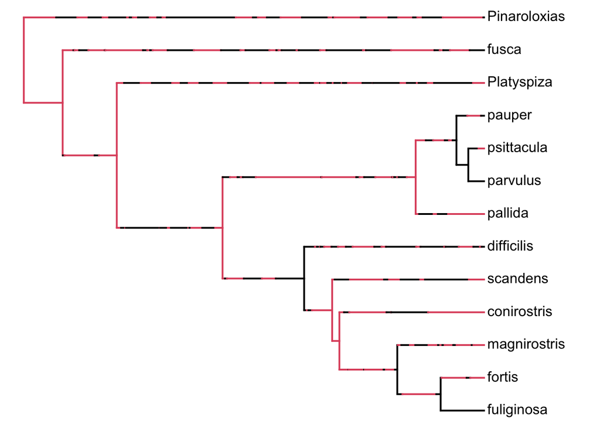

```
## no colors provided. using the following legend:
##         0         1
##   "black" "#DF536B"
```

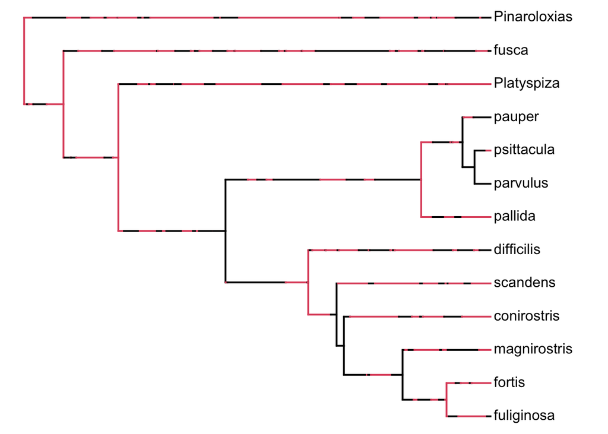

```r
#ER speicifies an equal rates model, this is one type of model that is used in discrete traits. The help documentation for `make.simmap` specifies that you can see the function `ace` to know what models are available to choose. If you scroll down to the "Details" section in the `ace` documentation it describes many different continuous and discrete trait models.


#let's see what this stochastic mapping actually does by plotting our results
plot(stoch.map)
```

```r
#you'll see when you look at the results from this analysis on the plots, you can see your biary trait recapitulated across the phylogenetic tree. Additionally, you can see that each of the 10 simulations we did are slightly different.
```

# contmap (phytools)

The ContMap function plots a tree with a mapped continuous character.

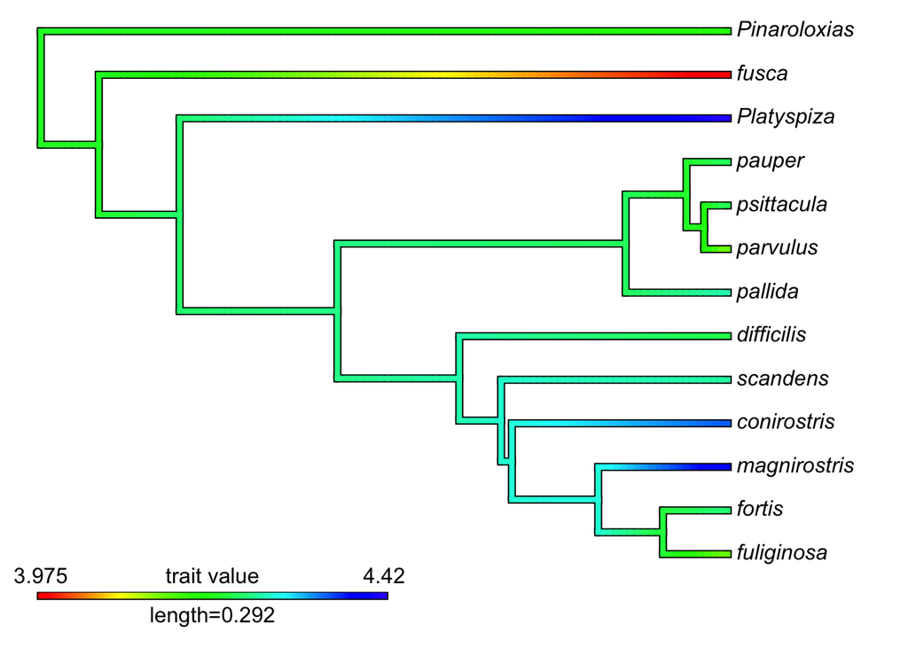

```r
contMap(tree, dat[,1])
```